# POLI 110

October 20, 2026

## Objectives

**Sampling Error**

- Review
- Random Sampling Error and Severity
- Sampling Error vs. Measurement Error
- Non-citizen Voting

## Example

### Was Charlie Kirk assassination a “wake-up call”?

- Some claim that “concern about political violence among Americans **increased** after the assassination”

## Sampling

### Key terms:

**population**: full set of cases (countries, individuals, etc.) we’re interested in describing

**sample**: a *subset* of the population that we observe and measure

**inference**: description of the (unmeasured) **population** we make *based on the (measured) **sample***

and there is **uncertainty** about what is true about the population, because we **only measure a sample**

The **population**:

> All American adults (18 years of age or older)

The **sample**:

> \(1381\) (June 2025), \(1477\) (September 2025) Americans 18+ “contacted … by text or online. Probability-based sampling frames include random-digit-dialing cell phone sample plus cellphone sample based on billing address.”

The **inference**:

> Americans say politically-motivated violence is a major problem: - 73% (\(\pm 2.3\)%) in June 2025 - 77% (\(\pm 2.1\)%) in September 2025

## Sampling

**random sampling**: sampling cases from the population in a manner that gives **all cases** an **equal probability** of being chosen.

This procedure creates **samples** that:

- give **unbiased** inferences about the population (**regardless of sample size**) (no sampling bias)
  - **unbiased** in that, across all samples, on average the sample averages are the same as the population average
- has **random sampling errors** with a known **size**: produces **known uncertainty** (described by the field of statistics)

### **sampling error**:

The difference between the value of the measure for the sample and the true value of the measure for the population

\[\mathrm{Value}_{sample} - \mathrm{Value}_{population} \neq 0 \xrightarrow{then} \mathrm{sampling \ error}\]

- Just like **measurement error**, there are two types: one that is **bias** and one that is **random**
- Sampling error is a **kind of measurement error**. If our measure requires inference about a *population*, sampling error *is* measurement error.

### **sampling error**:

When thinking about **random sampling error** and **sampling bias**, we should think about…

the **sampling distribution**: [See here](https://mdweaver.shinyapps.io/survey_sampling/)

- the results (e.g., sample average) from all possible samples we **could have gotten**, using this sampling procedure.
- we only ever get the result from the **one sample** we draw, but can **imagine** the results could have been different (counter-factually)
- it is **not** something we **actually know**, except in simulations

The **inference**:

Americans say politically-motivated violence is a major problem:

- 73% (\(\pm 2.3\)%) in June 2025
- 77% (\(\pm 2.1\)%) in September 2025 (after Kirk assassination)

Can we say concern about politically-motivated violence has gone up?

- What might a skeptic say?

If we **assume** random sampling, no **sampling bias** (or at least, the *same* sampling bias):

Skeptic might say:

> “It could be that concern about political violence remained at 73%, and the increase is due to random sampling error!”

## Random Sampling Error and Severity

Random sampling **always** involves **random sampling error** \(\to\) uncertainty

How might interpretation of evidence for claims be changed due to this random sampling error?

- We want to know whether we find evidence in support of some claim, EVEN IF THAT CLAIM WERE FALSE, due to **random sampling error** (by chance).
- We want to know “how severe” is this evidence? **How likely** could it lead us to wrong conclusions, **due to chance**?

(board, contrast w/ bias)

## Random Sampling Error and Severity

Unlike sampling bias, random sampling error \(\to\) a *knowable* uncertainty:

When sample size (\(n\)) \(\uparrow\)…

- random errors \(\downarrow\) in size
- *sampling distribution* \(\to\) approximately *normal*/“bell-shaped”

[See here](https://mdweaver.shinyapps.io/survey_sampling/)

## Random Sampling Error and Severity

One approach to assess severity is:

**hypothesis tests**: compare an “alternative” (claim is true) versus a “null” hypothesis (claim is false). Tell us probability of observing data for a claim **by chance**, if the claim were false. (**error probability**)

**alternative hypothesis (claim is correct)**

**null hypothesis (claim is incorrect)**

## Random Sampling Error and Severity

**hypothesis test** asks: “how likely are we to see this evidence for the claim, **assuming** that the claim **is false**”

- we **assume** the null hypothesis is right \(\to\) true concern is 73%
- we **assume** a random sampling procedure \(\to\) take random samples of \(1477\)
- with these two assumptions, we “make” the **sampling distribution** (in stats class, you plug into formulas)

We can imagine truth is 73% concerned about political violence; generate thousands of samples of size \(1477\); record the results

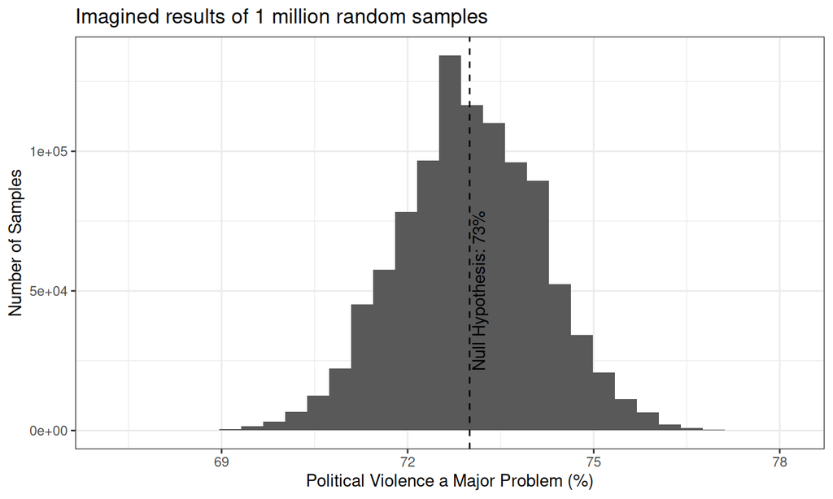

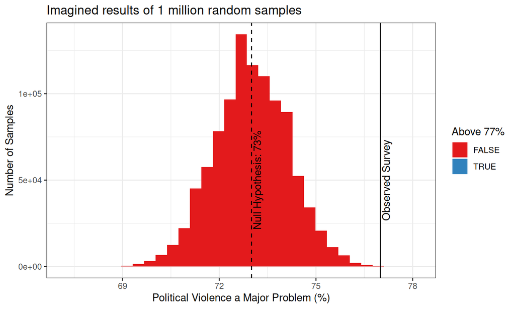

If true concern about political violence is 73%, by chance we see 77% concern or more with probability of 0.000172.

## Random Sampling Error and Severity

**hypothesis test** asks: “how likely are we to see this evidence, **assuming** that the claim **is false**”

- **\(p\)-value**: probability of accepting claim (rejecting the null hypothesis) due to chance, *if it were false*
- probability of **incorrectly** concluding that concern about political violence increased, due to random sampling error. (error is 0.0172% of the time)

## Random Sampling Error and Severity

\(p\) values:

- it is an **error probability** (probability of incorrectly accepting the claim)
- it is **advertised** *severity* of evidence (against random sampling error)
- \(p\) value of \(< 0.05\) is not magic. \(\to\) “could observe this 1 in 20 times if null hypothesis is true/claim is wrong”
- only meaningful if assumptions are correct (here: no bias, random sampling)

## Random Sampling Error and Severity

If we **assume** random sampling, no **sampling bias**:

Skeptic might say:

> “It could be that concern about political violence remained at 73%, and the increase is due to random sampling error!”

**null hypothesis**: there has been NO increase in concern (claim is wrong)

But we can respond:

> “We saw 77% of people concerned about political violence. If you were right, we’d see this only 0.0172% of the time

## Random Sampling Error and Severity

What is a **margin of error**/**confidence interval**, then?

- We **choose** an *error probability* that is “acceptable” \(\to\) 1% (how **severe** do we want our evidence to be?)
- Compare observed data (77% concerned about political violence) against **all possible** null hypotheses (0% to 100%).

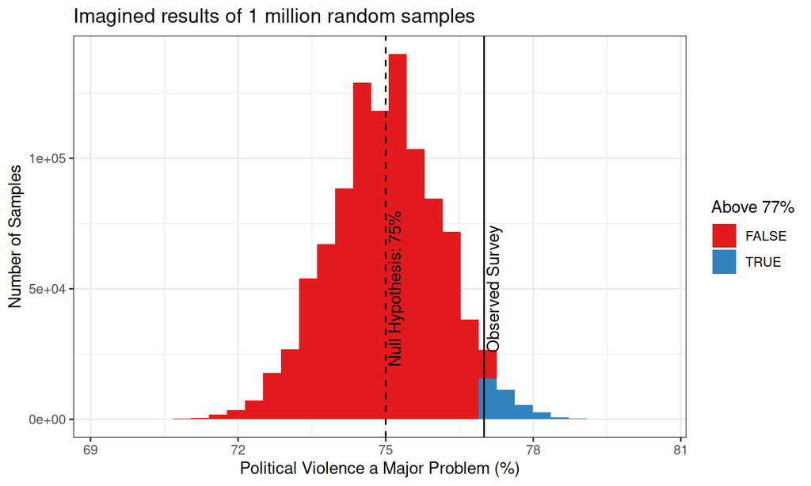

If true concern about political violence is 75%, by chance we see 77% concern or more with probability of 0.036425. Error rate of 3.6425\(\%\) \(> 1\%\) \(\to\) cannot reject 75%.

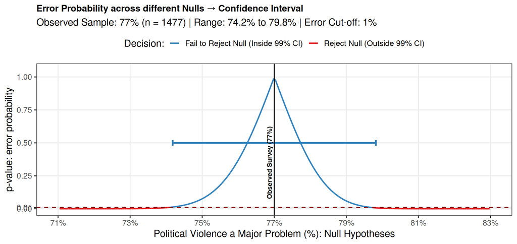

## Random Sampling Error and Severity

What is a **margin of error**/**confidence interval**, then?

- We **choose** an error probability that is “acceptable” \(\to\) 1% (how **severe** do we want our evidence to be?)
- Compare observed data (77% concerned about political violence) against **all possible** null hypotheses (0% to 100%).
- Range of values for “null hypotheses” we **cannot reject** with chosen error rate.
- Still assumes no sampling bias and use of random sampling
- 77% concerned \(\to\) reject truth being outside of range from 74.2% to 79.8% with error rate of 1% or less

## Random Sampling Error and Severity

What is a “margin of error” or “confidence interval”:

- If survey says it is \(50\% \pm 2\%\) with \(95\%\) confidence
- The true value is in the range of \(48-52\) with \(5\%\) *error probability*

## Random Sampling Error and Severity

If we have **random sampling errors**:

- we can put a number on probability of making an error \(\to\) quantify severity

If we have **sampling bias**…

- we’d need to think about: **direction** and **magnitude** to see if it could lead to weak severity

## Sampling Error?

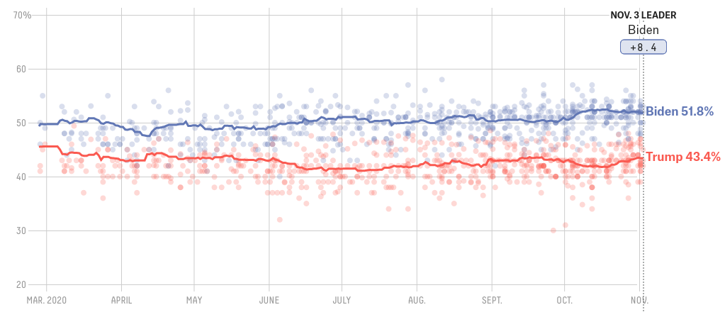

Surveys said voters preferred Biden to Trump by \(8.4\) percent. Biden **actually** won by only \(4.5\) points.

What might explain this?

## Sampling Error?

It depends: if this is going on, then sampling bias

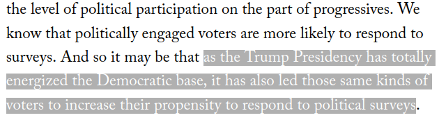

## Sampling Error?

It depends: if this is going on, then sampling bias

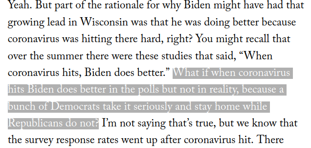

## Sampling Error?

It depends: if there are “shy” Trump voters, then measurement bias.

- when is there sampling error vs measurement error?
- what is sampling error a measurement error?

## Non Citizen Voting

## Voter Fraud

> In addition to winning the Electoral College in a landslide, I won the popular vote if you deduct the millions of people who voted illegally

> — Donald J. Trump (@realDonaldTrump) [November 27, 2016](https://twitter.com/realDonaldTrump/status/802972944532209664?ref_src=twsrc%5Etfw)

> White House senior advisor doubles down on voter fraud claims: “Voter fraud is a serious problem in this country” [pic.twitter.com/DC6lVPQznz](https://t.co/DC6lVPQznz)

> — ABC News (@ABC) [February 12, 2017](https://twitter.com/ABC/status/830787890309369856?ref_src=twsrc%5Etfw)

This “problem” used to justify policy changes:

- requirements to show proof of citizenship with ID when voting
- collect records on voter files at a national (not state) level
- federal investigations and prosecutions of alleged voter fraud
- threats against voter turnout NGOs

## Voter Fraud

Claim: Widespread voter fraud: “14% of non-citizens voted”

### **Concept**

- Non-citizen; voter fraud \(\xrightarrow{}\)

### **Variable**(s)

- Fraction of non-citizens who voted \(\xrightarrow{}\)

### **Measure**(s)

- how do we measure non-citizen voting? \(\xrightarrow{}\)

### Answer?

## Voter Fraud

[figure not shown]

## Voter Fraud

Richman et al:

- two large, random sample of adult Americans in 2008, 2010 (~**33,000 and 55,400 people**)
- identify a **sample of non-citizens**: respondents who indicate on the survey that they are non-citizens (\(N = 489\), or about \(1\%\) of people in 2010)

## Voter Fraud

### So, was Trump right?

**Discuss: Do you find this persuasive? Why or why not?**

## Two Big Problems:

### Problem One: Individual Measurement Error

The political scientists who run the CCES survey point out:

- Citizenship question suffers from (low) measurement error.
- Those surveyed in both 2010 and 2012: \(99.7\%\) gave the same answer on citizenship, \(0.19\%\) went from “non-citizen” to “citizen” (maybe true), \(0.11\%\) went from **“citizen” to “non-citizen” (definitely false)**
- **measurement error:** misclassifies \(0.1\%\) of people (1 out of a 1000)
- to the board

## Two Big Problems:

### Problem Two: Sampling Error

**measurement error** of individuals as citizens/non-citizens, leads Richman et al to sample of “non-citizens” that include **citizens** and non-citizens:

- citizens \(\gg\) non-citizens \(\to\) many more **citizens** who are **misclassified** as **“non-citizens”**
- We have **sampling error**… the sample does not reflect the population Richman et al want to make inferences about.
- It could be that the “non-citizen” voting is driven entirely by voting among citizens who clicked the wrong button on the survey.

## Two Big Problems:

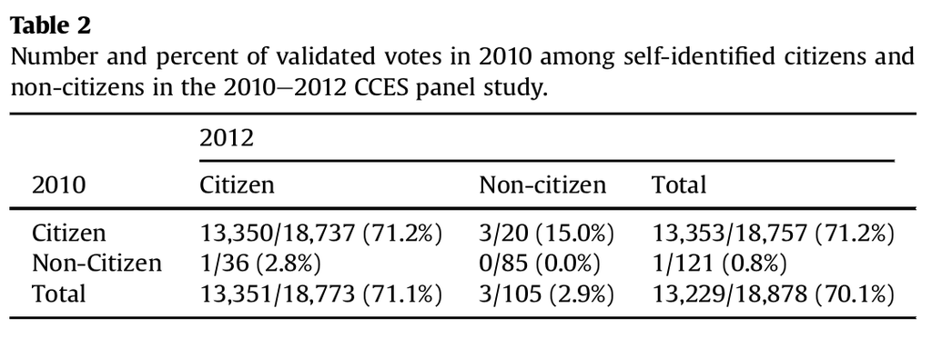

Nobody who consistently reports being a non-citizen votes.

## Two Big Problems:

**Measurement Error** (of individuals’ citizenship)

\(\Downarrow produces\)

**Sampling Error** (sample that should be of **non-citizens** includes **citizens**)

\(\Downarrow produces\)

**Measurement Error** (about the *population of non-citizens*)

\(\Downarrow\)

authors make incorrect inference that hundreds of thousands of non-citizens vote illegally.

## In more detail:

1. Richman et al/ Trump want to make claims about the **population** of all non-citizens. They use a **sample**.
2. The **sample** is generated based on individual survey responses to a questions that are **wrong** for \(0.1\%\) of individuals (individual **measurement error**)
3. This generates **sampling bias** as the sample systematically includes **citizens** in sample of “non-citizens”
4. Because Richman et al/ Trump are using the sample to make inferences about the **population** of non-citizens, the **sampling bias** produces **measurement bias** (of population): systematically over-estimating non-citizen voting.

## Example 2:

When is **sampling error** *not* **measurement error**?

- If you are not trying to make an inference about a population, sampling error doesn’t generate measurement error.

## Conclusion

## Descriptive Claims

People try to persuade you there is a problem in need of fixing:

- illegal actions by migrants
- increasing crime
- levels of political violence
- declines in democracy

Is this problem real?

## Descriptive Claims

- Concept \(\to\) is definition systematic/transparent?
- Variable/validity \(\to\) Does variable capture concept? Does choice of variable lead us to support claim even if it is false?
- Measure/measurement error \(\to\) Do measurement strategies lead to error? What kind of error? Does this error lead us to support claim even if it is false?